# PCA

Ian Douglas

9/25/2019

```r
library(corrplot)
library(tidyverse)
```

# 1 Load in the functional connectivity and dissimilarity data

-Also read in the labels for plotting purposes

```r
fcon = readRDS('../data/processed/funcConnectivity.rds')
fdis = readRDS('../data/processed/functionalDist.rds')
if (nrow(fcon) == nrow(fdis) & ncol(fcon) == ncol(fdis))
  {dim(list(fcon, fdis)[[sample(1:2,1)]])}
```

```
## [1]  149 2346
```

# 2 Conduct principal components analysis

-Note that there are more variables than participants, so the lowest dimensional space in which to project the principal components is equal to $n$, not $p$.

```r
funcPCA = prcomp(fcon, scale. = TRUE, center = TRUE, retx = TRUE)
saveRDS(funcPCA, '../results/PCA/funcConnectivityPCAobj.rds')
distPCA = prcomp(fdis, scale. = TRUE, center = TRUE, retx = TRUE)
saveRDS(distPCA, '../results/PCA/funcDissimilarityPCAobj.rds')
```

Explanation: the `funcPCA` is produced from a set of variables, for which each participant has one score for each pair of brain regions (combinations of size 2 of 69 different units) summing to 2346 variables. Each score is the Pearson correlation between the preprocessed time series of each brain region with that of each other brain region.

The `distPCA` object is derived from the same process, except that instead of computing the correlation between each time series, a measure of the dissimilarity between the two time series is calculated which is based on pearson correlation. For this reason the results are expected to be similar.

### 2.0.1 Correlation between the solutions

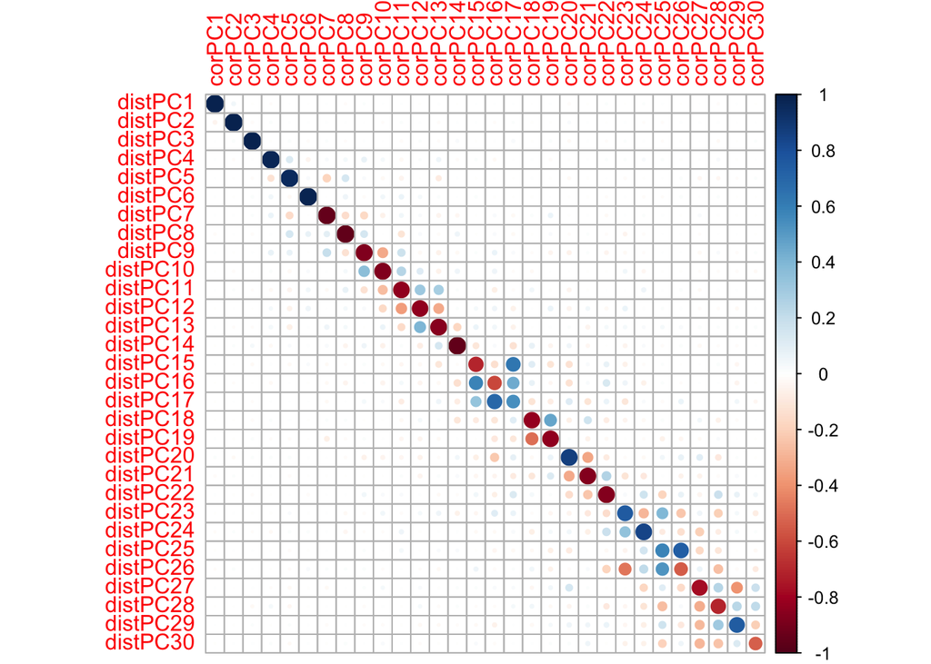

```r
pcCorr = cor(cbind(distPCA$x, funcPCA$x))
nm = c(paste0("distPC",1:ncol(distPCA$x)),
       paste0("corPC",1:ncol(funcPCA$x)))
rownames(pcCorr) <- nm; colnames(pcCorr) <- nm
methodCompareCor <- as.matrix(pcCorr[1:149, 150:298])
# visualize the correlation between the first 30 dimensions across each method
corrplot(methodCompareCor[1:30,1:30])
```

As expected the methods are highly correlated.

### 2.0.2 Plot the percentage of the variance explained:

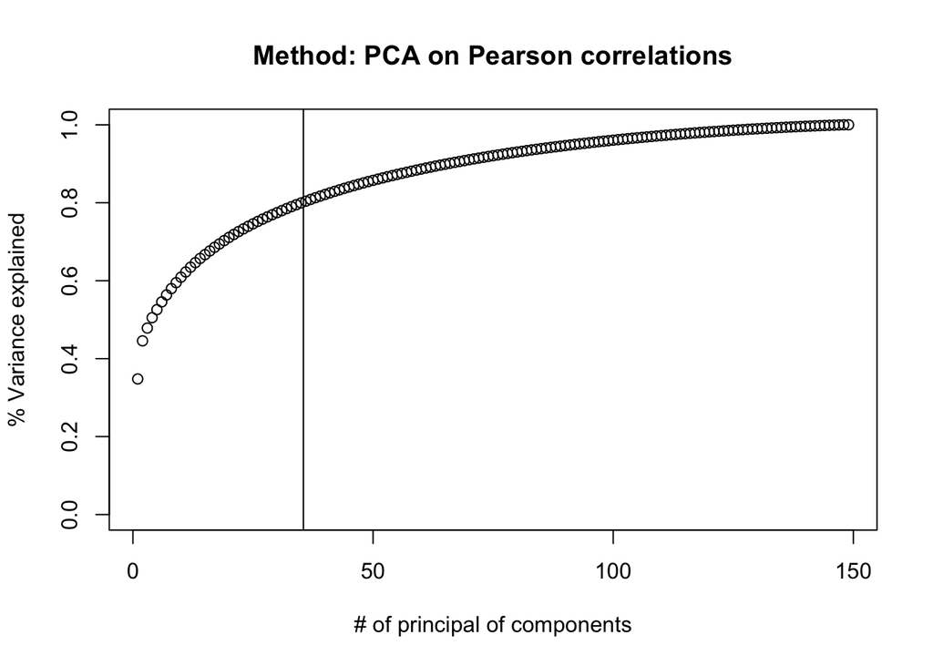

```r
plot(1:length(funcPCA$sdev), cumsum(funcPCA$sdev^2/2346),
     ylab = '% Variance explained',
     xlab = '# of principal of components',
     main = 'Method: PCA on Pearson correlations',
     ylim = c(0,1))
abline(v = mean(c(tail(which(cumsum(funcPCA$sdev^2/2346)<.8),1),
                  which(cumsum(funcPCA$sdev^2/2346)>.8)[1])))
```

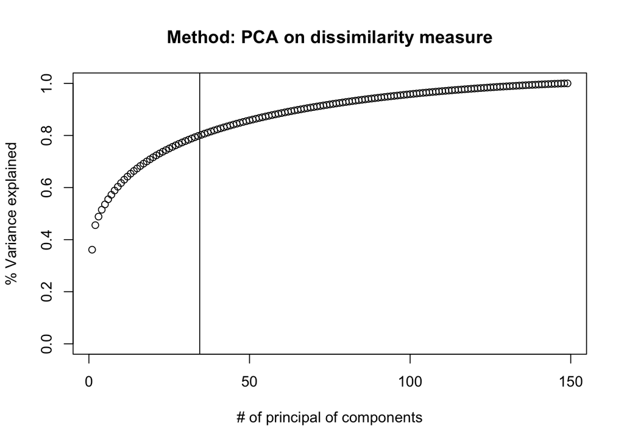

```r
plot(1:length(distPCA$sdev), cumsum(distPCA$sdev^2/2346),
     ylab = '% Variance explained',
     xlab = '# of principal of components',
     main = 'Method: PCA on dissimilarity measure',
     ylim = c(0,1))
abline(v = mean(c(tail(which(cumsum(distPCA$sdev^2/2346)<.8),1),
                  which(cumsum(distPCA$sdev^2/2346)>.8)[1])))
```

### 2.0.3 Projection plots

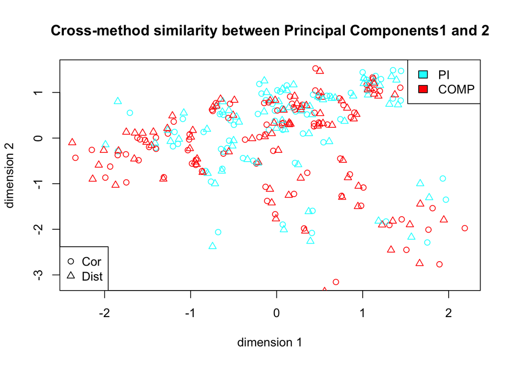

This plot shows where the participants have ended up (their “PC scores”) along dimensions 1 and 2. The circles represent those projections, one for each participant, as a result of conducting PCA on the pearson correlations, while the triangle-shaped points are the projections for the same individuals, but when the PCs are computed from the dissimilarity metric.

# 3 Assess the variable loadings on each component

```r
dim1loadings = data.frame("PC1" = funcPCA$rotation[,1],
                          "var" = names(funcPCA$rotation[,1]),
                          stringsAsFactors = FALSE) %>%
  arrange(desc(abs(PC1)))
dim2loadings=data.frame("PC2" = funcPCA$rotation[,2],
                          "var" = names(funcPCA$rotation[,2]),
                          stringsAsFactors = FALSE) %>%
  arrange(desc(abs(PC2)))
head(dim1loadings[1:10,])
```

|  | PC1 | var |
| --- | --- | --- |
| 1 | -0.02947969 | harvardox_cortical_41.X.harvardox_cortical_30 |
| 2 | -0.02928291 | harvardox_subcortical_2.X.harvardox_cortical_6 |
| 3 | -0.02927945 | harvardox_cortical_7.X.harvardox_cortical_28 |
| 4 | -0.02915564 | harvardox_cortical_6.X.harvardox_cortical_30 |
| 5 | -0.02912383 | harvardox_cortical_43.X.harvardox_cortical_33 |
| 6 | -0.02903859 | harvardox_cortical_46.X.harvardox_cortical_28 |

```r
head(dim2loadings[1:10,])
```

|  | PC2 | var |
| --- | --- | --- |
| 1 | -0.05242843 | harvardox_subcortical_21.X.harvardox_cortical_41 |
| 2 | -0.05195816 | harvardox_cortical_5.X.harvardox_cortical_41 |
| 3 | -0.05116066 | harvardox_cortical_9.X.harvardox_cortical_44 |
| 4 | -0.05114465 | harvardox_cortical_9.X.harvardox_cortical_2 |
| 5 | -0.05111732 | harvardox_subcortical_6.X.harvardox_subcortical_10 |
| 6 | -0.05063780 | harvardox_cortical_41.X.harvardox_cortical_27 |